# Assingment 02

tony sulfaro

3/1/2019

# load the libraries

```r
library(tidyverse)
library("lubridate")
```

# load the data

```r
music_data <- read_csv("out_data.csv")
```

```r
#transform(music_data, timestamp = as.Date(timestamp))
```

# Add Additional Columns

```r
# ID column
# https://stackoverflow.com/questions/23518605/add-an-index-numeric-id-column-to-large-data-frame
#music_data <- tibble::rowid_to_column(music_data, "ID")
#music_data$day <- weekdays(as.Date(music_data$timestamp))

# date col to factor variable

# count times by day
```

# Questions

## What day(s) do I listen to music and how many days did I listen for more than 30 minutes that day?

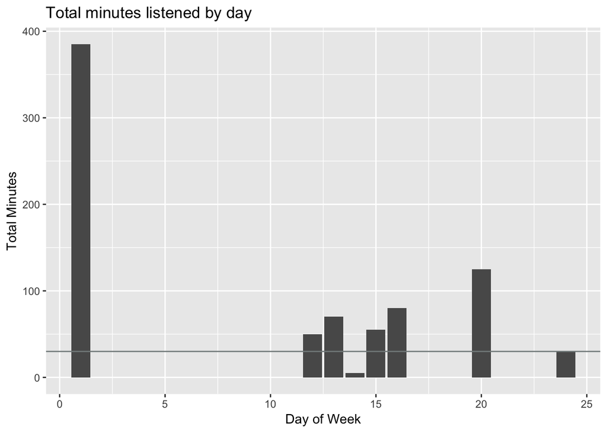

```r
# aggregate geom bar
# https://stackoverflow.com/questions/40260048/geom-bar-tied-exactly-to-x-and-y-axis-without-aggregating
ggplot(data = music_data) +
  geom_bar(mapping = aes(x=day, y=duration),stat = "identity")+
  geom_hline(aes(yintercept=30), colour="#838B8B")+

  ggtitle("Total minutes listened by day") +
  xlab("Day of Week") +
  ylab("Total Minutes")
```

## How many listening sessions were over 30 min?

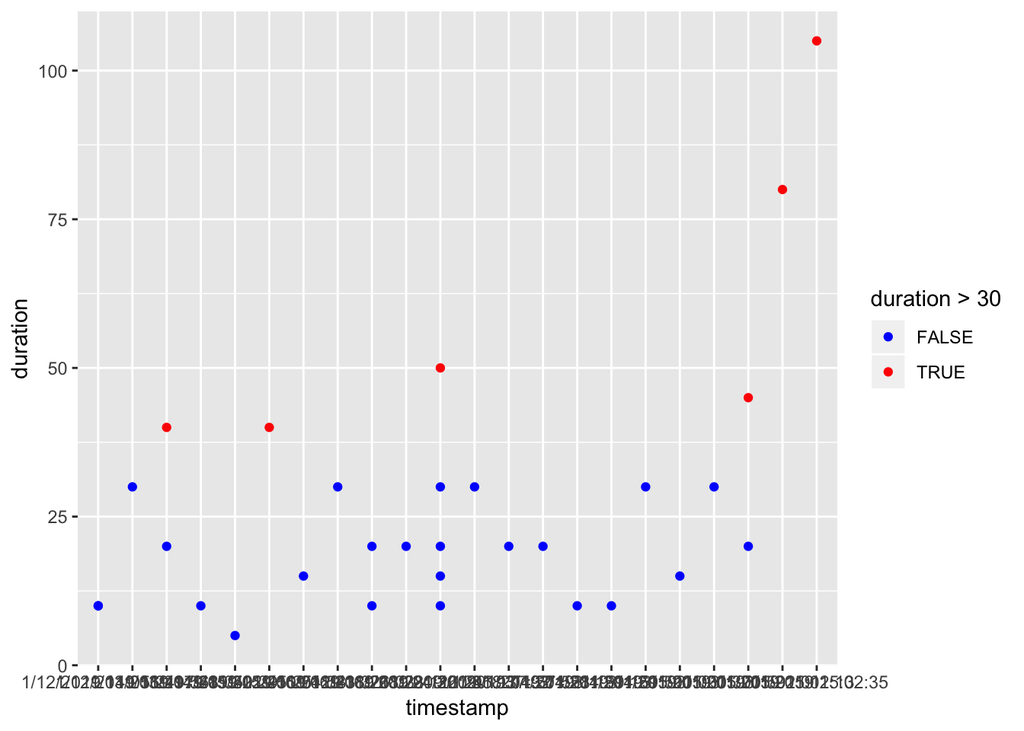

```r
ggplot(data = music_data) +
  geom_point(mapping = aes(x=timestamp, y=duration, colour = duration > 30))+
  scale_color_manual(values = c("blue", "red"))
```

## What genre(s) of music do I listen to the most?

[figure not shown]

```r
ggplot(data = music_data) +
  geom_bar(mapping = aes(x=music_genre))+
  ggtitle("Total minutes listened by music genre") +
  xlab("Music Genre") +
  ylab("Total Minutes")
```

# Appendix

### Description

```r
str(music_data)
```

```
## Classes 'spec_tbl_df', 'tbl_df', 'tbl' and 'data.frame': 30 obs. of  12 variables:
##  $ timestamp  : chr  "1/12/2019 14:05:24" "1/12/2019 14:05:24" "1/12/2019 16:19:56" "1/13/2019 17:48:04" ...
##  $ year       : num  2019 2019 2019 2019 2019 ...
##  $ month      : num  1 1 1 1 1 1 1 1 1 1 ...
##  $ day        : num  12 12 12 13 13 13 14 15 15 16 ...
##  $ hour       : num  14 14 16 17 17 19 22 10 12 18 ...
##  $ minute     : chr  "05" "05" "19" "48" ...
##  $ second     : chr  "24" "24" "56" "04" ...
##  $ music_genre: chr  "Electronic" "Rock" "Hip Hop/Rap" "Rock" ...
##  $ task       : chr  "Cleaning" "Cleaning" "Homework" "Driving" ...
##  $ location   : chr  "Living Room" "Living Room" "Living Room" "Car" ...
##  $ duration   : num  10 10 30 40 20 10 5 40 15 30 ...
##  $ services   : chr  "Spotify" "Spotify" "Spotify" "Spotify" ...
##  - attr(*, "spec")=
##   .. cols(
##   ..   timestamp = col_character(),
##   ..   year = col_double(),
##   ..   month = col_double(),
##   ..   day = col_double(),
##   ..   hour = col_double(),
##   ..   minute = col_character(),
##   ..   second = col_character(),
##   ..   music_genre = col_character(),
##   ..   task = col_character(),
##   ..   location = col_character(),
##   ..   duration = col_double(),
##   ..   services = col_character()
##   .. )
```

## Usage:

```r
music_data
```

```
## # A tibble: 30 x 12
##    timestamp  year month   day  hour minute second music_genre task
##    <chr>     <dbl> <dbl> <dbl> <dbl> <chr>  <chr>  <chr>       <chr>
##  1 1/12/201…  2019     1    12    14 05     24     Electronic  Clea…
##  2 1/12/201…  2019     1    12    14 05     24     Rock        Clea…
##  3 1/12/201…  2019     1    12    16 19     56     Hip Hop/Rap Home…
##  4 1/13/201…  2019     1    13    17 48     04     Rock        Driv…
##  5 1/13/201…  2019     1    13    17 48     04     Country     Driv…
##  6 1/13/201…  2019     1    13    19 50     29     Hip Hop/Rap Driv…
##  7 1/14/201…  2019     1    14    22 45     25     Rock        Driv…
##  8 1/15/201…  2019     1    15    10 04     58     Country     Home…
##  9 1/15/201…  2019     1    15    12 43     32     Hip Hop/Rap Walk…
## 10 1/16/201…  2019     1    16    18 26     03     Hip Hop/Rap Lift…
## # … with 20 more rows, and 3 more variables: location <chr>,
## #   duration <dbl>, services <chr>
```

## Format:

### Dimensions:

Number of rows = 30

Number of columns = 12

### Column definitions:

- year - year timestamp
- month - month timestamp
- day - day timestamp
- hour - hour timestamp
- minute - minute timestamp
- second - second timestamp
- music_genre - genre of music listened to
- task - what I was doing while listening to music
- location - where I was listening to music
- duration - how long I listened to music
- service - what service was used to listen to the music

# Essay

### Background:

The theme of this particular assingment was to apply what we learned during lab and use those methods an apply it to our dataset.

### Questions:

- What day(s) do I listen to music and how many days did I listen for more than 30 minutes that day?
- What genre(s) of music do I listen to the most?

### Generating the Graph:

While reading in the data into a dataframe is pretty cool from a technical standpoint, to the average user (and even technical ones) it is hard to derive meaning from looking at the raw data. To solve this issue I created several visualizations to illustrate patterns and trends in my personal music listening habits.

### Influence from Lecture 04:

Initially, I did not have much direction with how I was visualizing data. I used bar charts, pie charts, and tree maps to try and show which genre(s) were most popular or what days in particular I listened to music the most. While these visualizations from assingment 1 helped quantify the data, the colors used were confusing and didn’t help to suppliment to the information.

Lecture 04 helped me use color meaningfully by coloring points to help quantify data. For example, to show that a point has a higher value you can color it darker than ones with lower values. This can show at a glance which points have high and low values without having to reference the y-axis. Additionally, if you add a line to represent a threshhold, you can color points above and below the line different colors to show margins more clearly when points are crowded together.